[figure not shown]

# Simulación de modelos mixtos

Freddy Hernández

2019-febrero-02

## Introducción

En esta publicación se mostrará al lector cómo simular datos de modelos lineales y la forma de estimar los parámetros. Los modelos a simular son:

1. Modelo lineal clásico,
2. Modelo lineal con intercepto aleatorio,
3. Modelo lineal con pendiente aleatoria,
4. Modelo lineal con intercepto y pendiente aleatoria.

## Ilustración de un modelo mixto

Se recomienda al lector que visite el enlace mostrado abajo para que vea una ilustración muy interesante de modelos mixtos. Los parámetros usados en las simulaciones fueron inspirados en la ilustración.

http://mfviz.com/hierarchical-models/

## Simulando datos de modelo lineal clásico

Suponga que queremos simular $n=50$ observaciones del siguiente modelo con vector de parámetros $\boldsymbol{\Theta}=(\beta_0=59, \beta_1=1, \sigma=1)^\top$.

$$\begin{align*}
y_i &\sim \mathcal{N}(\mu_i, \sigma^2) \\
\mu_i &= 59 + 1 x_i \\
\sigma &= 1 \\
x &\sim Uniforme[1, 9]
\end{align*}$$

Con el siguiente código se simula el conjunto de datos de interés.

```r
n <- 50
x <- sample(1:9, size=n, replace=TRUE) # Uniforme discreta [1, 9]
sig <- 1
media <- 59 + 1 * x
y <- rnorm(n=n, mean=media, sd=sig)
```

Vamos a construir un diagrama de dispersión para los datos simulados.

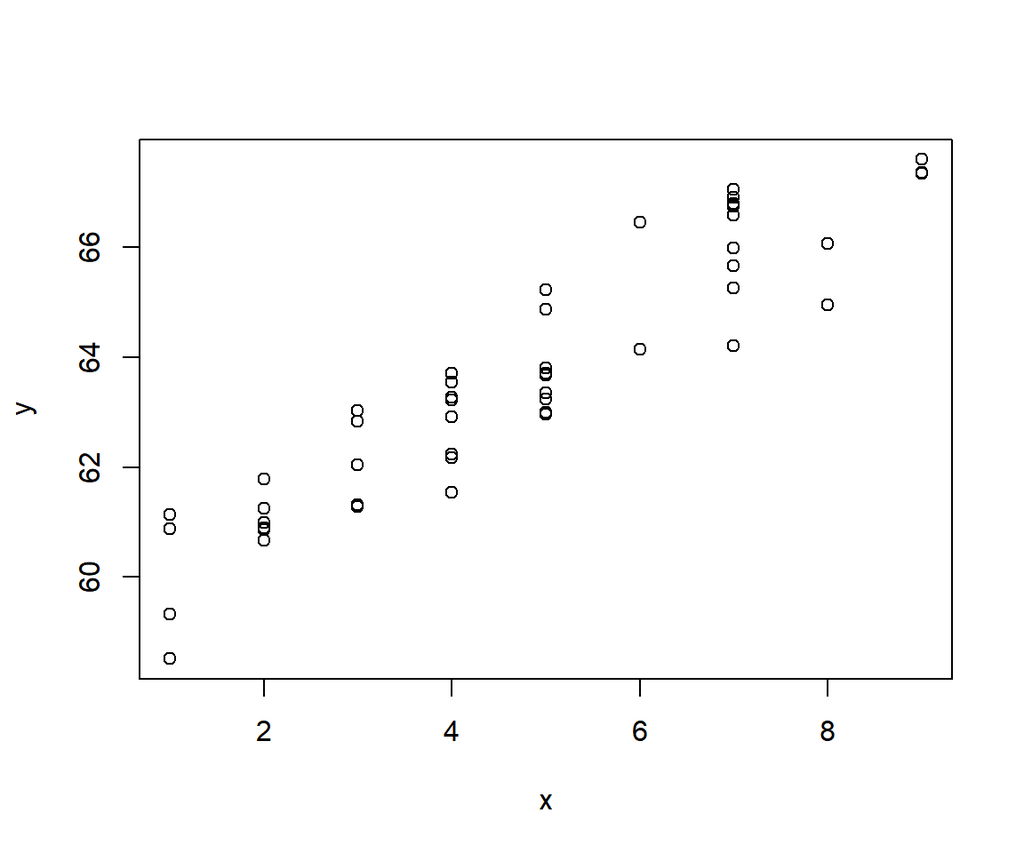

```r
plot(y ~ x)
```

Ajustemos un modelo para recuperar el vector de parámetros parámetros $\boldsymbol{\Theta}$.

```r
mod1 <- lm(y ~ x)
c(mod1$coef, sigma=summary(mod1)$sigma)
```

```
## (Intercept)           x       sigma
##  59.1080602   0.9532924   0.8458667
```

De la salida anterior vemos que vector de parámetros estimado está cerca de $\boldsymbol{\Theta}=(\beta_0=59, \beta_1=1, \sigma=1)^\top$.

Vamos a agregar la línea del modelo ajustado.

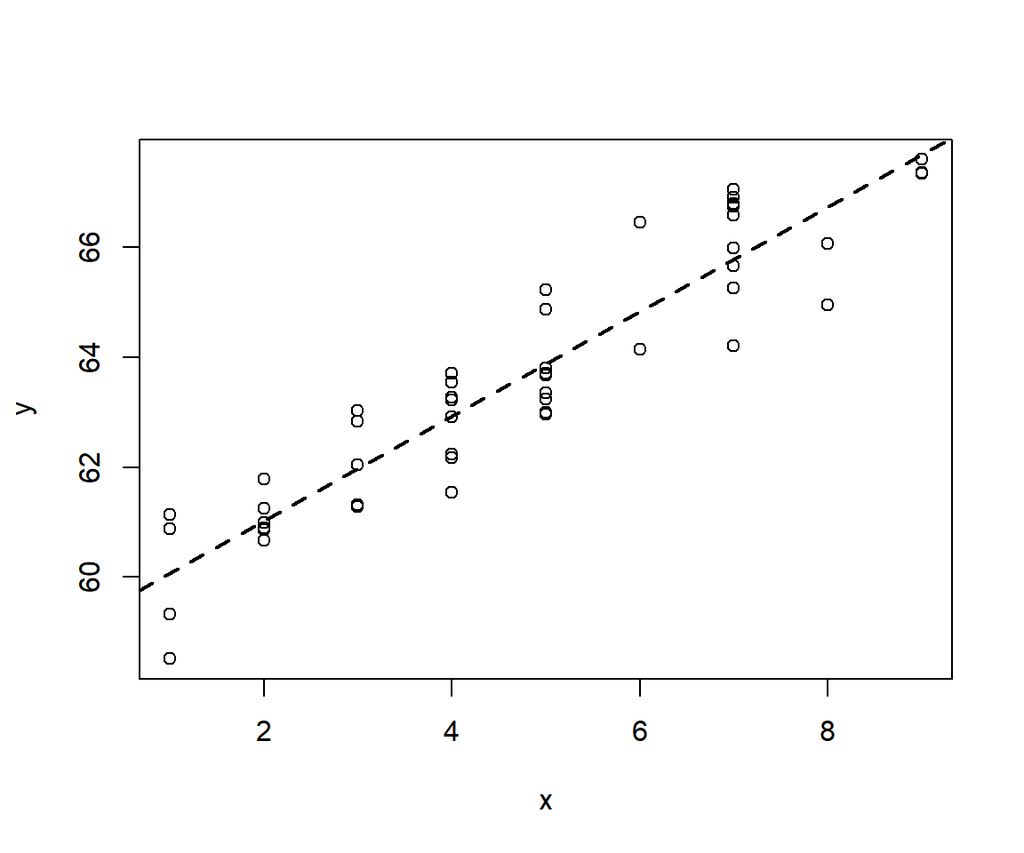

```r
plot(y ~ x)
abline(mod1, lty='dashed', lwd=2)
```

## Simulando datos con intercepto aleatorio

Suponga que ahora queremos simular $n_i=10$ observaciones para $n_g=5$ grupos (en total 50) usando el siguiente modelo mixto con intercepto aleatorio con vector de parámetros $\boldsymbol{\Theta}=(\beta_0=59, \beta_1=1, \sigma=1, \sigma_{b0}=10)^\top$.

$$\begin{align*}
y_{ij} &\sim \mathcal{N}(\mu_{ij}, \sigma^2) \\
\mu_{ij} &= 59 + 1 \, x_{ij} + b_{0i} \\
\sigma &= 1 \\
b_0 &\sim \mathcal{N}(0, \sigma_{b0}^2) \\
x &\sim Uniforme[1, 9] \\
i &= 1, 2, \ldots, n_g \quad j=1, 2, \ldots, n_i
\end{align*}$$

```r
sig <- 1
sd_b0 <- 10

ng <- 5        # número de grupos
ni <- 10       # número de obs por grupo
n <- ng * ni   # número de obs total

grupo <- rep(1:5, each=ni) # Variable de agrupación

x <- sample(1:9, size=n, replace=TRUE)
b0 <- rnorm(n=ng, mean=0, sd=sd_b0)  # Vector con los cinco b0
b0_rep <- rep(b0, each=ni)           # Vector con los b0 repetidos
media <- 59 + 1 * x + b0_rep
y <- rnorm(n=n, mean=media, sd=sig)

dt <- data.frame(grupo=grupo, x=x, b0_rep, y=y)
```

Exploremos lo que hay dentro de `dt`.

```r
dt[1:15, ]
```

```
##    grupo x    b0_rep        y
## 1      1 6 -3.218891 61.91027
## 2      1 9 -3.218891 65.04719
## 3      1 9 -3.218891 64.62184
## 4      1 2 -3.218891 56.09529
## 5      1 9 -3.218891 66.30427
## 6      1 7 -3.218891 62.99862
## 7      1 3 -3.218891 61.73813
## 8      1 8 -3.218891 64.25754
## 9      1 4 -3.218891 59.26677
## 10     1 7 -3.218891 62.20549
## 11     2 7 -4.313491 61.76769
## 12     2 7 -4.313491 60.98198
## 13     2 7 -4.313491 60.71319
## 14     2 8 -4.313491 64.55310
## 15     2 6 -4.313491 61.53866
```

Vamos a construir un diagrama de dispersión para los datos simulados.

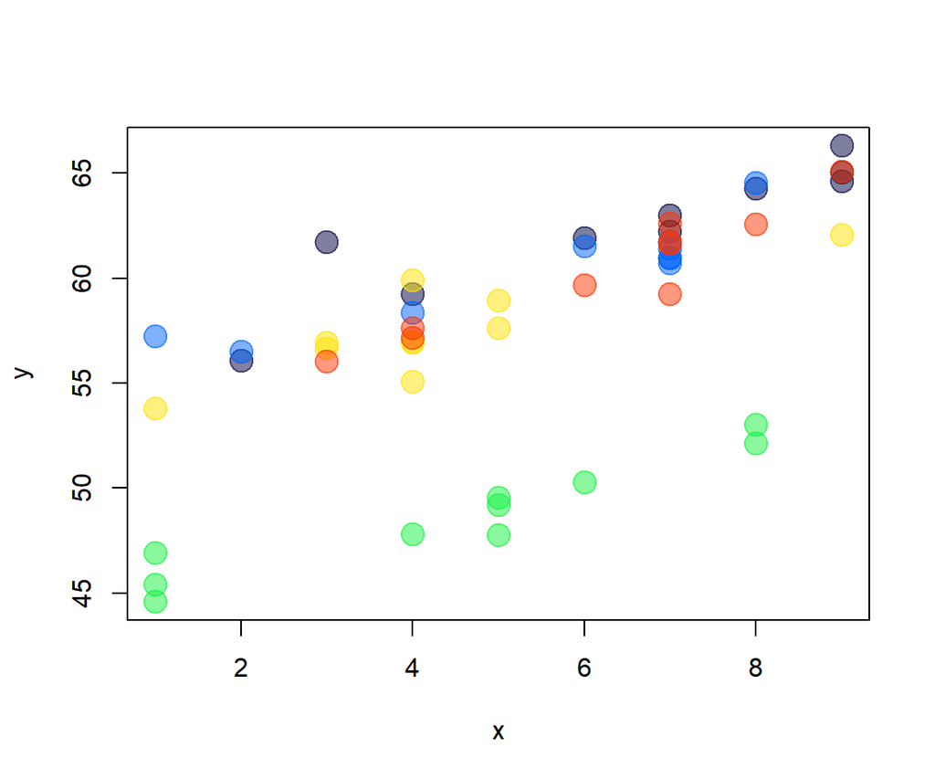

```r
colores <- c("#00004080", "#0063FF80", "#13F24080", "#FFE20180", "#FF330080")
with(dt, plot(y ~ x, pch=20, col=colores[dt$grupo], cex=3))
```

Ajustemos un modelo para recuperar el vector de parámetros parámetros $\boldsymbol{\Theta}$, para esto usemos la función `lme` del paquete `nlme`.

```r
library(nlme)
mod2 <- lme(y ~ x, random = ~ 1 | grupo, data=dt)
summary(mod2)
```

```
## Linear mixed-effects model fit by REML
##  Data: dt
##        AIC     BIC    logLik
##   185.5972 193.082 -88.79858
##
## Random effects:
##  Formula: ~1 | grupo
##         (Intercept) Residual
## StdDev:      4.6725 1.125244
##
## Fixed effects: y ~ x
##                Value Std.Error DF  t-value p-value
## (Intercept) 52.28896 2.1302767 44 24.54562       0
## x            1.04092 0.0713615 44 14.58652       0
##  Correlation:
##   (Intr)
## x -0.18
##
## Standardized Within-Group Residuals:
##        Min         Q1        Med         Q3        Max
## -1.9552468 -0.5005675 -0.1218938  0.4778389  2.5353105
##
## Number of Observations: 50
## Number of Groups: 5
```

De la tabla anterior vemos que el vector de parámetros estimado $\hat{\boldsymbol{\Theta}}$ no está tan alejado de $\boldsymbol{\Theta}$.

Los efectos fijos estimados $\beta_0$ y $\beta_1$ se obtienen así:

```r
fixef(mod2)
```

```
## (Intercept)           x
##   52.288957    1.040916
```

Vamos a recuperar las predicciones de los 5 interceptos aleatorios (efectos aleatorios) y a compararlas con los verdaderos $b_{0}$.

```r
cbind(ranef(mod2), b0)
```

```
##   (Intercept)         b0
## 1   3.4735786  -3.218891
## 2   2.2674453  -4.313491
## 3  -8.1494277 -14.890850
## 4   0.8271488  -5.932020
## 5   1.5812549  -4.412089
```

Usando los efectos fijos y los efectos aleatorios podemos obtener las expresiones ($\hat{\beta}_0 + \hat{\beta}_1 x_{ij} + b_{0i}$) para los modelos de cada grupo así:

```r
coef(mod2)
```

```
##   (Intercept)        x
## 1    55.76254 1.040916
## 2    54.55640 1.040916
## 3    44.13953 1.040916
## 4    53.11611 1.040916
## 5    53.87021 1.040916
```

Usando la información anterior se puede dibujar el modelo ajustado para cada grupo.

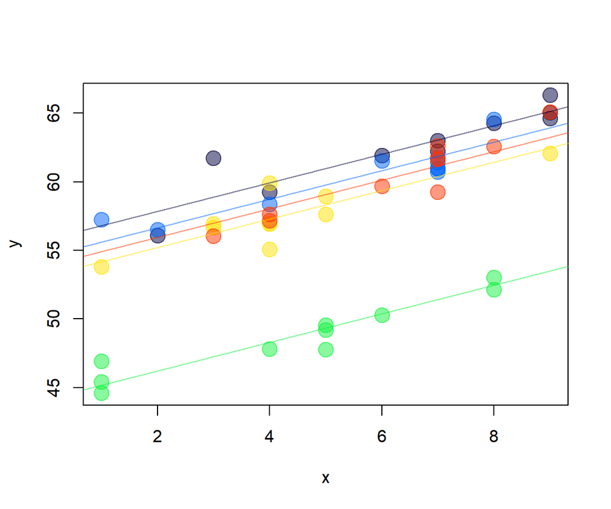

```r
coef <- coef(mod2)
with(dt, plot(y ~ x, pch=20, col=colores[dt$grupo], cex=3))
for (i in 1:5) abline(a=coef[i, 1], b=coef[i, 2], col=colores[i])
```

## Simulando datos con pendiente aleatoria

$$\begin{align*}
y_{ij} &\sim \mathcal{N}(\mu_{ij}, \sigma^2) \\
\mu_{ij} &= 59 + 1 \, x_{ij} + b_{1i} \, x_{ij} \\
\sigma &= 1 \\
b_1 &\sim \mathcal{N}(0, \sigma_{b1}^2) \\
x &\sim Uniforme[1, 9] \\
i &= 1, 2, \ldots, n_g, \quad j=1, 2, \ldots, n_i
\end{align*}$$

```r
sig <- 1
sd_b1 <- 5

ng <- 5
ni <- 10
n <- ng * ni

grupo <- rep(1:5, each=ni)
n <- ng * ni
x <- sample(1:9, size=n, replace=TRUE)
b1 <- rnorm(n=ng, mean=0, sd=sd_b0)
b1_rep <- rep(b0, each=ni)
media <- 59 + 1 * x + b1_rep * x
y <- rnorm(n=n, mean=media, sd=sig)

dt <- data.frame(grupo=grupo, x=x, b1_rep, y=y)
```

Exploremos lo que hay dentro de `dt`.

```r
dt[1:15, ]
```

```
##    grupo x    b1_rep        y
## 1      1 2 -3.218891 54.64262
## 2      1 8 -3.218891 40.78853
## 3      1 5 -3.218891 48.26462
## 4      1 8 -3.218891 42.02471
## 5      1 8 -3.218891 40.90763
## 6      1 3 -3.218891 51.19602
## 7      1 4 -3.218891 50.55825
## 8      1 2 -3.218891 56.70711
## 9      1 4 -3.218891 50.96907
## 10     1 7 -3.218891 43.39652
## 11     2 3 -4.313491 47.81310
## 12     2 5 -4.313491 42.56684
## 13     2 9 -4.313491 28.33917
## 14     2 4 -4.313491 45.63265
## 15     2 9 -4.313491 28.94701
```

Vamos a construir un diagrama de dispersión para los datos simulados.

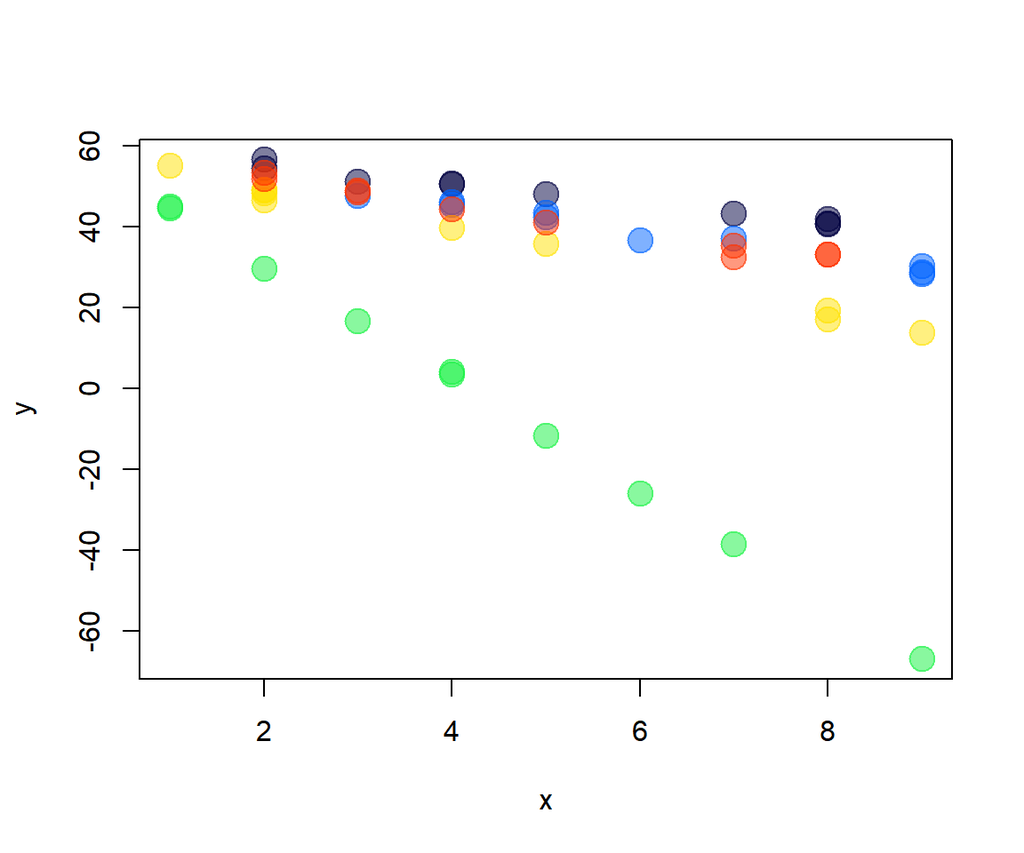

```r
with(dt, plot(y ~ x, pch=20, col=colores[dt$grupo], cex=3))
```

Ajustemos un modelo para recuperar el vector de parámetros parámetros $\boldsymbol{\Theta}$, para esto usemos la función `lme` del paquete `nlme`.

```r
mod3 <- lme(y ~ x, random = ~ -1 + x | grupo, data=dt)
summary(mod3)
```

```
## Linear mixed-effects model fit by REML
##  Data: dt
##        AIC      BIC    logLik
##   198.8367 206.3215 -95.41836
##
## Random effects:
##  Formula: ~-1 + x | grupo
##                x Residual
## StdDev: 4.806376 1.115056
##
## Fixed effects: y ~ x
##                Value Std.Error DF   t-value p-value
## (Intercept) 59.05108 0.3469201 44 170.21523  0.0000
## x           -5.58540 2.1504111 44  -2.59736  0.0127
##  Correlation:
##   (Intr)
## x -0.026
##
## Standardized Within-Group Residuals:
##         Min          Q1         Med          Q3         Max
## -2.29390560 -0.51749261  0.07463635  0.54589759  1.85256443
##
## Number of Observations: 50
## Number of Groups: 5
```

Los efectos fijos estimados $\beta_0$ y $\beta_1$ se obtienen así:

```r
fixef(mod3)
```

```
## (Intercept)           x
##   59.051081   -5.585396
```

```r
cbind(ranef(mod3), b1)
```

```
##            x        b1
## 1  3.3805563 -9.308715
## 2  2.2678243  3.875562
## 3 -8.4085106  6.243570
## 4  0.5723769  9.874831
## 5  2.1877531 -3.144305
```

Usando los efectos fijos y los efectos aleatorios podemos obtener las expresiones ($\hat{\beta}_0 + \hat{\beta}_1 x_{ij} + b_{1i} x_{ij}$) para los modelos de cada grupo así:

```r
coef(mod3)
```

```
##   (Intercept)          x
## 1    59.05108  -2.204840
## 2    59.05108  -3.317572
## 3    59.05108 -13.993907
## 4    59.05108  -5.013019
## 5    59.05108  -3.397643
```

Usando la información anterior se puede dibujar el modelo ajustado para cada grupo.

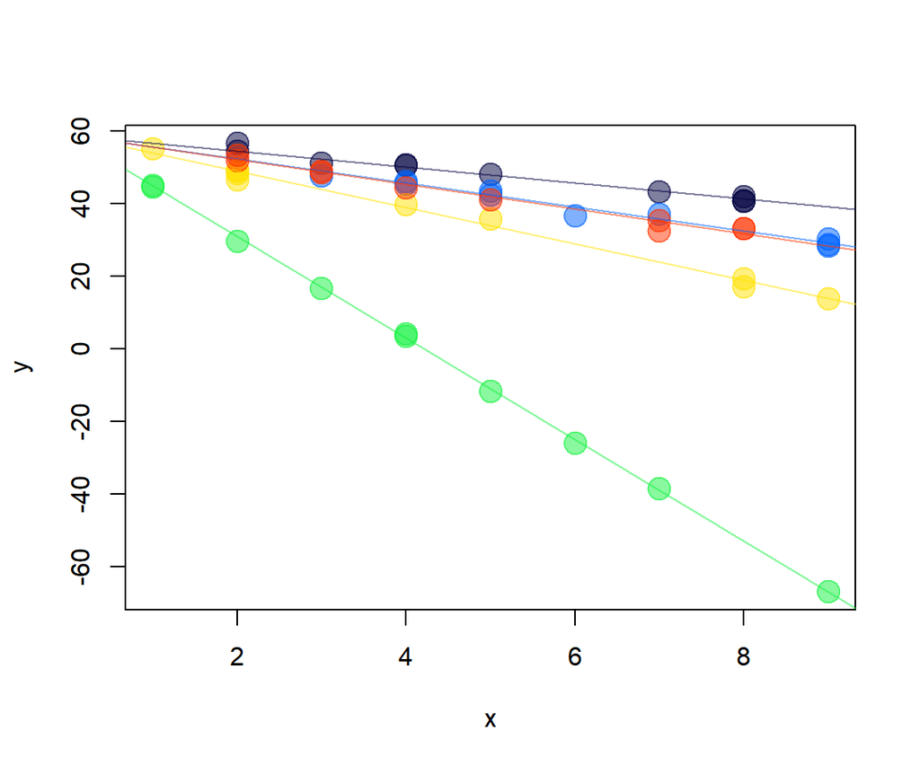

```r
coef <- coef(mod3)
with(dt, plot(y ~ x, pch=20, col=colores[dt$grupo], cex=3))
for (i in 1:5) abline(a=coef[i, 1], b=coef[i, 2], col=colores[i])
```

## Simulando datos con intercepto y pendiente aleatoria

Suponga que ahora queremos simular $n_i=10$ observaciones para $n_g=5$ grupos (en total 50) usando el siguiente modelo mixto con intercepto y pendiente aleatoria con vector de parámetros $\boldsymbol{\Theta}=(\beta_0=59, \beta_1=1, \sigma=1, \sigma_{b0}=9, \sigma_{b0}=4, \sigma_{b01}=-2)^\top$.

$$\begin{equation}
\begin{split}
y_{ij} &\sim \mathcal{N}(\mu_{ij}, \sigma^2), \\
\mu_{ij} &= 59 + 1 \, x_{ij} + b_{0i} + b_{1i} \, x_{ij} \\
\left (
\begin{matrix}
b_{0i} \\ b_{1i}
\end{matrix}
\right ) &\sim
\mathcal{N}\left ( \left ( \begin{matrix}
0 \\ 0
\end{matrix} \right ),
\left ( \begin{matrix}
\sigma^2_{b0} & \sigma_{b01} \\
\sigma_{b01} & \sigma^2_{b1}
\end{matrix} \right )
\right ) \\
x &\sim Uniforme[1, 9] \\
i &= 1, 2, \ldots, n_g \quad j=1, 2, \ldots, n_i
\end{split}
\end{equation}$$

```r
ng <- 5
ni <- 10
n <- ng * ni

sig <- 1

sd_b0 <- 9     # Matriz de covarianzas de los efectos aleatorios
sd_b1 <- 4
sd_b0b1 <- -2

library(MASS)
mu <- c(0, 0)
Sigma <- matrix(c(sd_b0^2, sd_b0b1, sd_b0b1, sd_b1^2), ncol=2)
b <- mvrnorm(n=ng, mu=mu, Sigma=Sigma)
b_rep <- b[rep(1:nrow(b), each=ni), ]

grupo <- rep(1:5, each=ni)
x <- sample(1:9, size=n, replace=TRUE)
media <- 59 + 1 * x + b_rep[, 1] + b_rep[, 2] * x
y <- rnorm(n=n, mean=media, sd=sig)

dt <- data.frame(grupo=grupo, x=x, b0=b_rep[, 1], b1=b_rep[, 2], y=y)
```

Exploremos lo que hay dentro de `dt`.

```r
dt[1:15, ]
```

```
##    grupo x         b0        b1        y
## 1      1 3   5.372668 -1.200423 65.69929
## 2      1 8   5.372668 -1.200423 63.58149
## 3      1 7   5.372668 -1.200423 62.20279
## 4      1 3   5.372668 -1.200423 64.00904
## 5      1 1   5.372668 -1.200423 63.67912
## 6      1 7   5.372668 -1.200423 63.51440
## 7      1 6   5.372668 -1.200423 61.91097
## 8      1 1   5.372668 -1.200423 62.65201
## 9      1 6   5.372668 -1.200423 63.75670
## 10     1 6   5.372668 -1.200423 63.79679
## 11     2 9 -19.159190  2.891419 75.26568
## 12     2 4 -19.159190  2.891419 57.27368
## 13     2 5 -19.159190  2.891419 61.39001
## 14     2 6 -19.159190  2.891419 62.36861
## 15     2 2 -19.159190  2.891419 46.42691
```

Vamos a construir un diagrama de dispersión para los datos simulados.

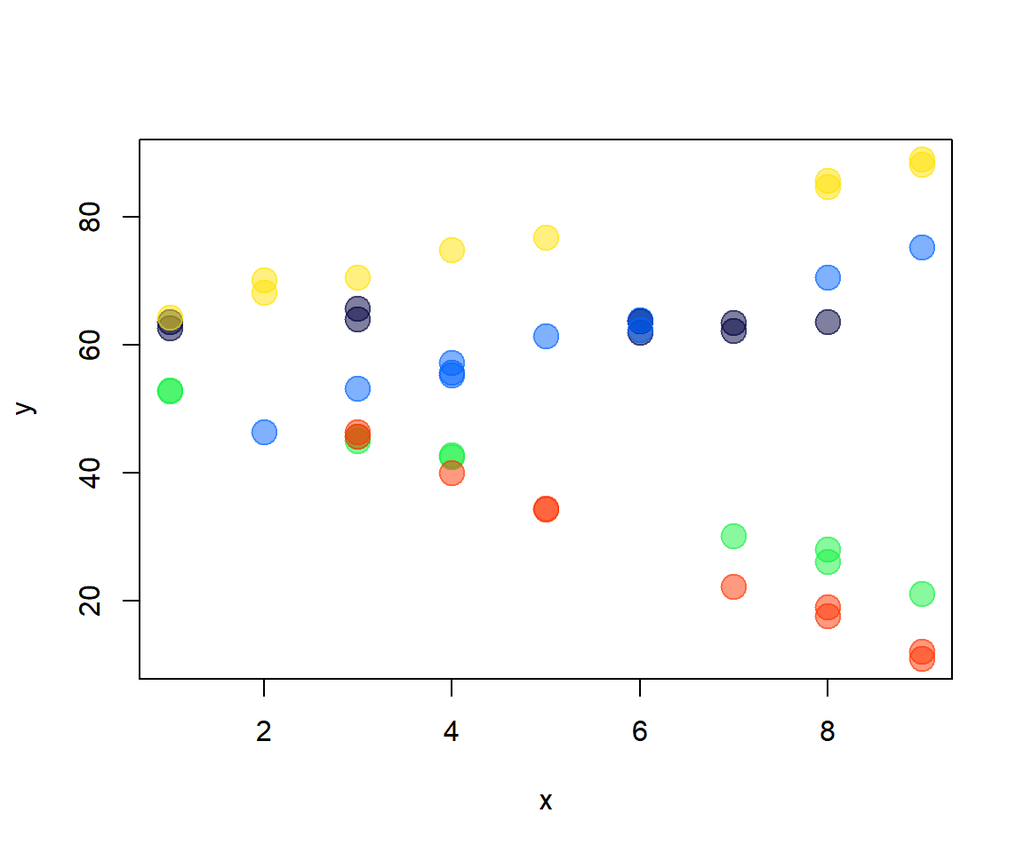

```r
with(dt, plot(y ~ x, pch=20, col=colores[dt$grupo], cex=3))
```

Ajustemos un modelo para recuperar el vector de parámetros parámetros $\boldsymbol{\Theta}$, para esto usemos la función `lme` del paquete `nlme`.

```r
mod4 <- lme(y ~ x, random = ~ 1 + x | grupo, data=dt)
summary(mod4)
```

```
## Linear mixed-effects model fit by REML
##  Data: dt
##        AIC      BIC    logLik
##   212.0749 223.3021 -100.0374
##
## Random effects:
##  Formula: ~1 + x | grupo
##  Structure: General positive-definite, Log-Cholesky parametrization
##             StdDev    Corr
## (Intercept) 9.7826745 (Intr)
## x           4.1230381 -0.491
## Residual    0.9998006
##
## Fixed effects: y ~ x
##                Value Std.Error DF   t-value p-value
## (Intercept) 57.41008  4.387741 44 13.084200  0.0000
## x           -0.58082  1.844784 44 -0.314842  0.7544
##  Correlation:
##   (Intr)
## x -0.491
##
## Standardized Within-Group Residuals:
##        Min         Q1        Med         Q3        Max
## -1.8506336 -0.6316114 -0.1076669  0.4383002  2.0536973
##
## Number of Observations: 50
## Number of Groups: 5
```

Al igual que en los ejemplos anteriores, se puede dibujar el modelo ajustado para cada grupo.

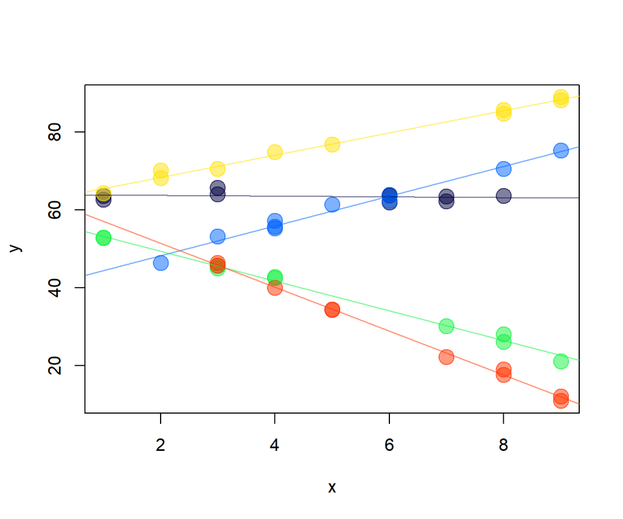

```r
coef <- coef(mod4)
with(dt, plot(y ~ x, pch=20, col=colores[dt$grupo], cex=3))
for (i in 1:5) abline(a=coef[i, 1], b=coef[i, 2], col=colores[i])
```

## Tarea

1. ¿Es posible que en un modelo mixto $y$ se distribuya no normal?
2. Consultar en la web ejemplos sencillos (con una sola covariable $x$) de modelos mixtos en los cuales la variable respuesta siga una distribución Poisson, binomial y gamma.
3. Para cada uno de los ejemplos encontrados, simular datos usando la estructura del ejemplo y luego estimar los parámetros.

Fin